# Portfoliomanagement and Financial Analysis - Assignment 7

Submit until Monday 2020-11-23, 13:00

Winder, Anna-Sophie

```r
#remotes::install_github("braverock/FactorAnalytics",  build_vignettes = TRUE, force = TRUE)
pacman::p_load(tidyverse,tidyquant,FFdownload,FactorAnalytics,PerformanceAnalytics)
install.packages("psych")
```

```
Error in install.packages : Updating loaded packages
```

```r
library("psych")
```

**Please** remember to put your assignment solutions in `rmd` format using **many** chunks and putting readable text in between, similar to my examples given in Research Methods and Assignment 1!

For all exercises: Please use the Assignment-Forum to post your questions, I will try my best to help you along!

## Exercise 1: Analysing the CAPM

In this exercise we want to estimate the CAPM. Please read carefully through the two documents provided (right hand side: files). Then we start to collect the necessary data:

1. From Datastream get the last 10 years of data from the 100 stocks of the S&P100 using the list `LS&P100I` (S&P 100): total return index (RI) and market cap (MV)
2. Further import the Fama-French-Factors from Kenneth Frenchs homepage (monthly, e.g. using `FFdownload`). From both datasets we select data for the last (available) 60 months, calculate returns (simple percentage) for the US-Stocks and eliminate those stocks that have NAs for this period.
3. Now subtract the risk-free rate from all the stocks. Then estimate each stocks beta with the market: Regress all stock excess returns on the market excess return and save all betas (optimally use `mutate` and `map` in combination with `lm`). Estimate the mean-return for each stock and plot the return/beta-combinations. Create the security market line and include it in the plot! What do you find?
4. In a next step (following both documents), we sort the stocks according to their beta and build ten value-weighted portfolios (with more or less the same number of stocks). Repeat a) for the ten portfolios. What do you observe?
5. In the third step you follow page 6-8 of the second document and estimate the second-pass regression with the market and then market & idiosyncratic risk. What do you observe? Present all your results in a similar fashion as in the document.

## Exercise 2: Performance Evaluation I

Read Chapter 24 of our book. In this exercise use a Minimum Variance and a Tangecy (maxium Sharpe Ratio) portfolio calculate from your stocks, as well as the S&P500 as a benchmark (Period 2000-01-01 - 2020-01-11). For all three Investment Opportunities imagine you invest 100USD per month into the portfolio. What is the overall return this investment provides you? How much should you have investd at the bginning (one-time investment) to get the eact same overall wealth at the end of 2020? Can you plot both wealth developments over time?

First of all, I am going to download all the crucial data, which we need in order to create the three portfolios. My personal stock choice are Apple, Nividia, Microsoft, American Express, Walmart, Bank of America, Morgan Stanley, Disney, Exxon Mobile. As the benchmark we take the S&P500, regarding to the underling task.

```r
install.packages("FinCal",dependencies=TRUE)
library(timetk,PortfolioAnalytics)
SP500 <- tq_index("SP500")
```

```
Getting holdings for SP500
```

```r
stock_names <- c("AAPL", "NVDA", "MSFT", "AXP", "WMT", "BAC", "GS","MS", "DIS", "XOM")
```

```r
stock_returns <-tq_get(x = stock_names,get  = "stock.prices", from = "2000-01-01", to   = "2020-11-18") %>%
    group_by(symbol) %>%
    tq_transmute(select     = adjusted,
                 mutate_fun = periodReturn,
                 period     = "monthly")
unique(stock_returns$symbol)
```

```
 [1] "AAPL" "NVDA" "MSFT" "AXP"  "WMT"  "BAC"  "GS"   "MS"   "DIS"  "XOM"
```

```r
stock_returns_xts <- stock_returns %>%
                      subset( select = c(symbol,date, monthly.returns)) %>%
                      pivot_wider(names_from = symbol,
                                  values_from = monthly.returns) %>%
                      tk_xts(date_var = date, silent = TRUE)
stock_returns_xts
```

[output not shown]

[output cut: 148 more lines]

[output not shown]

```r
port <- portfolio.spec(assets=stock_names)%>%
  add.constraint(type="full_investment") %>% #In our approach we use full_investment as our task it is
  add.constraint(type="long_only") %>% #We do not take any short-selling
  add.objective(type="return", name="mean")
port
```

```
PortfolioAnalytics Portfolio Specification

Call:
portfolio.spec(assets = stock_names)

Number of assets: 10
Asset Names
 [1] "AAPL" "NVDA" "MSFT" "AXP"  "WMT"  "BAC"  "GS"   "MS"   "DIS"  "XOM"

Constraints
Enabled constraint types
        - full_investment
        - long_only

Objectives:
Enabled objective names
        - mean
```

Now I defined the investment constrains for our investments, which is based on our task a full investment constrained, due to the fact that we would like to be fully invested the whole period. The long only constrain comes from the idea that we are just caring about the upper part of the efficient frontier, in order to construct the tangency portfolio, which is the **most efficient** way to set our 10 stocks together concerning the faced risked. So, in order words the tangency portfolio maximizes the Sharpe Ratio. The second portfolio we have to construct is the Minimum-Variance Portfolio. The *“third”* portfolio would be an absolute passive strategy we would just invest in the SP500.

```r
opt_port <- optimize.portfolio(R=stock_returns_xts, portfolio=port,
                                 optimize_method="ROI", trace=TRUE)
opt_port
```

```
PortfolioAnalytics Optimization

Call:
optimize.portfolio(R = stock_returns_xts, portfolio = port, optimize_method = "ROI",
    trace = TRUE)

Optimal Weights:
AAPL NVDA MSFT  AXP  WMT  BAC   GS   MS  DIS  XOM
   0    1    0    0    0    0    0    0    0    0

Objective Measure:
   mean
0.03487
```

So, as we see we would make the most money if we would just everything in Nividia. However, we do not look for the maximum return, we look for the maximum return in relation to the taken risk.

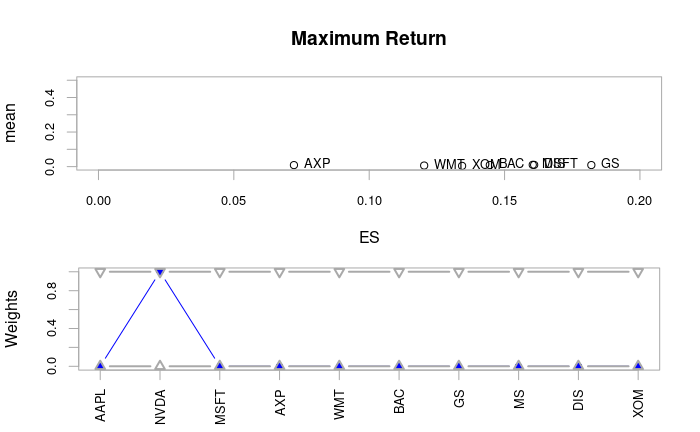

```r
plot(opt_port, chart.assets=TRUE, main="Maximum Return",
      xlim=c(0, 0.2), ylim=c(0,0.5))
```

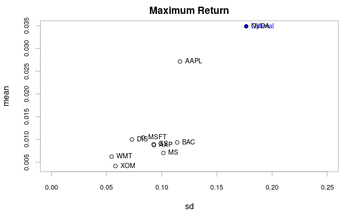

```r
chart.RiskReward(opt_port,return.col="mean", risk.col="sd",
                 chart.assets=TRUE,
                 xlim=c(0, 0.25),
                 main="Maximum Return")
```

```r
frontier <- create.EfficientFrontier(R=stock_returns_xts,
                                       portfolio=port,
                                       type="mean-StdDev")
```

```
executing %dopar% sequentially: no parallel backend registered
```

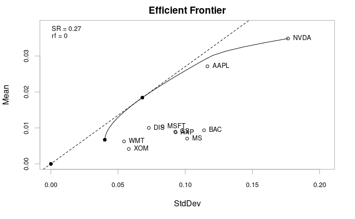

```r
chart.EfficientFrontier(frontier, match.col="StdDev", type="l",rf = 0, tangent.line = TRUE, chart.assets = TRUE,)
```

The efficient frontier is the set of optimal portfolios that offer the highest expected return for a defined level of risk or the lowest risk for a given level of expected return. Portfolios that lie below the efficient frontier are sub-optimal because they do not provide enough return for the level of risk.

```r
port_tan <- portfolio.spec(assets=stock_names) %>%
  add.constraint(type="full_investment") %>%
  add.constraint(type = "long_only") %>%
  add.objective(type="return", name="mean")
port_tan
```

```
PortfolioAnalytics Portfolio Specification

Call:
portfolio.spec(assets = stock_names)

Number of assets: 10
Asset Names
 [1] "AAPL" "NVDA" "MSFT" "AXP"  "WMT"  "BAC"  "GS"   "MS"   "DIS"  "XOM"

Constraints
Enabled constraint types
        - full_investment
        - long_only

Objectives:
Enabled objective names
        - mean
```

```r
init.portf <- portfolio.spec(assets=stock_names)
init.portf <- add.constraint(portfolio=init.portf, type="full_investment")
init.portf <- add.constraint(portfolio=init.portf, type="long_only")
init.portf <- add.objective(portfolio=init.portf, type="return", name="mean")
init.portf <- add.objective(portfolio=init.portf, type="risk", name="StdDev")
init.portf
```

```
PortfolioAnalytics Portfolio Specification

Call:
portfolio.spec(assets = stock_names)

Number of assets: 10
Asset Names
 [1] "AAPL" "NVDA" "MSFT" "AXP"  "WMT"  "BAC"  "GS"   "MS"   "DIS"  "XOM"

Constraints
Enabled constraint types
        - full_investment
        - long_only

Objectives:
Enabled objective names
        - mean
        - StdDev
```

Maximizing the Sharpe Ratio can be formulated as a quadratic programming problem and solved very quickly using optimize_method=“ROI”. Although “StdDev” was specified as an objective, the quadratic programming problem uses the variance-covariance matrix in the objective function.

The default actin if “mean” and “StdDev” are specified as objectives with optimize_method=“ROI” is to maximize quadratic utility. If we want to maximize Sharpe Ratio, we need to pass in maxSR=TRUE to optimize the portfolio, which should lead us to the tangency portfolio.

```r
maxSR.lo.ROI <- optimize.portfolio(R=stock_returns_xts, portfolio=init.portf, optimize_methode="ROI", maxSR=TRUE, trace=TRUE)
```

```
Leverage constraint min_sum and max_sum are restrictive,
              consider relaxing. e.g. 'full_investment' constraint should be min_sum=0.99 and max_sum=1.01
```

[output not shown]

```r
maxSR.lo.ROI
```

```
PortfolioAnalytics Optimization

Call:
optimize.portfolio(R = stock_returns_xts, portfolio = init.portf,
    trace = TRUE, optimize_methode = "ROI", maxSR = TRUE)

Optimal Weights:
 AAPL  NVDA  MSFT   AXP   WMT   BAC    GS    MS   DIS   XOM
0.102 0.028 0.008 0.088 0.250 0.044 0.024 0.006 0.024 0.426

Objective Measures:
    mean
0.008826


 StdDev
0.04544
```

```r
maxSR.lo.RP <- optimize.portfolio(R=stock_returns_xts, portfolio=init.portf, optimize_method="random", search_size=2000, trace=TRUE)
```

```
Leverage constraint min_sum and max_sum are restrictive,
              consider relaxing. e.g. 'full_investment' constraint should be min_sum=0.99 and max_sum=1.01
```

```r
maxSR.lo.RP
```

```
PortfolioAnalytics Optimization

Call:
optimize.portfolio(R = stock_returns_xts, portfolio = init.portf,
    optimize_method = "random", search_size = 2000, trace = TRUE)

Optimal Weights:
 AAPL  NVDA  MSFT   AXP   WMT   BAC    GS    MS   DIS   XOM
0.000 0.050 0.028 0.088 0.286 0.000 0.020 0.062 0.190 0.276

Objective Measures:
    mean
0.008244


StdDev
0.0458
```

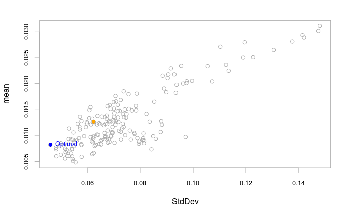

```r
chart.RiskReward(maxSR.lo.RP, risk.col="StdDev", return.col="mean")
```

```r
maxSR.lo.DE <- optimize.portfolio(R=stock_returns_xts, portfolio=init.portf, optimize_method="DEoptim", search_size=2000, trace=TRUE)
```

```
Leverage constraint min_sum and max_sum are restrictive,
              consider relaxing. e.g. 'full_investment' constraint should be min_sum=0.99 and max_sum=1.01
```

[output not shown]

```r
maxSR.lo.DE
```

```
PortfolioAnalytics Optimization

Call:
optimize.portfolio(R = stock_returns_xts, portfolio = init.portf,
    optimize_method = "DEoptim", search_size = 2000, trace = TRUE)

Optimal Weights:
 AAPL  NVDA  MSFT   AXP   WMT   BAC    GS    MS   DIS   XOM
0.032 0.062 0.056 0.008 0.274 0.010 0.030 0.004 0.038 0.486

Objective Measures:
    mean
0.008174


StdDev
0.0447
```

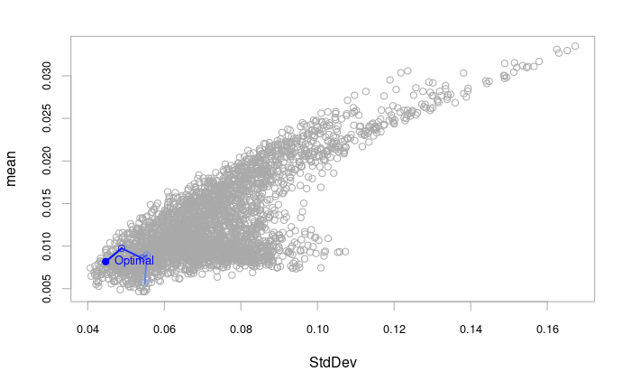

```r
chart.RiskReward(maxSR.lo.DE, risk.col="StdDev", return.col="mean")
```

The Minmimum Variance Portfolio minimizing the variance of the portfolio

```r
port_minvar <- portfolio.spec(assets=stock_names) %>%
  add.constraint(type="full_investment") %>%
  add.constraint(type = "long_only") %>%
  add.objective(type="risk", name="var")
port_minvar
```

```
PortfolioAnalytics Portfolio Specification

Call:
portfolio.spec(assets = stock_names)

Number of assets: 10
Asset Names
 [1] "AAPL" "NVDA" "MSFT" "AXP"  "WMT"  "BAC"  "GS"   "MS"   "DIS"  "XOM"

Constraints
Enabled constraint types
        - full_investment
        - long_only

Objectives:
Enabled objective names
        - var
```

```r
opt_minvar <- optimize.portfolio(R = stock_returns_xts,portfolio = port_minvar,
                              optimize_method = "ROI", trace = TRUE)
opt_minvar
```

```
PortfolioAnalytics Optimization

Call:
optimize.portfolio(R = stock_returns_xts, portfolio = port_minvar,
    optimize_method = "ROI", trace = TRUE)

Optimal Weights:
  AAPL   NVDA   MSFT    AXP    WMT    BAC     GS     MS    DIS    XOM
0.0241 0.0000 0.0615 0.0000 0.4551 0.0000 0.0000 0.0000 0.1094 0.3499

Objective Measure:
 StdDev
0.04021
```

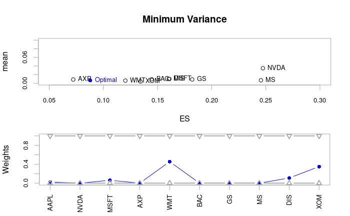

```r
plot(opt_minvar, chart.assets=TRUE, main="Minimum Variance",
      xlim=c(0.05, 0.3), ylim=c(0,0.1))
```

So, as we can see we see that we would invest the majority of our capital in Walmart and Exxon Mobile, due to the low standard deviation and quiet interesting we would not invest in Nividia.

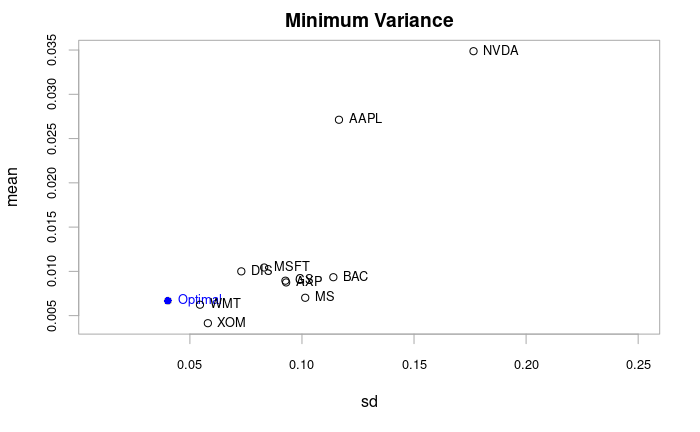

```r
chart.RiskReward(opt_minvar,return.col="mean", risk.col="sd",
                 chart.assets=TRUE,
                 xlim=c(0.01, 0.25),
                 main="Minimum Variance")
```

```r
wts_tan <- c(0.136, 0.006, 0.000, 0.000, 0.440, 0.018, 0.154, 0.002, 0.000, 0.244)
wts_minvar <- c(0.0241, 0.0000, 0.0615, 0.0000, 0.4551, 0.0000, 0.0000, 0.0000, 0.1094, 0.3499)# Weights from the Minimum Variance Portfolio
```

Portfolio Returns

```r
stock_returns
```

| symbol | date | monthly.returns |
| --- | --- | --- |
| AAPL | 2000-01-31 | -7.314352e-02 |
| AAPL | 2000-02-29 | 1.048197e-01 |
| AAPL | 2000-03-31 | 1.848407e-01 |
| AAPL | 2000-04-28 | -8.651603e-02 |
| AAPL | 2000-05-31 | -3.229218e-01 |
| AAPL | 2000-06-30 | 2.470245e-01 |
| AAPL | 2000-07-31 | -2.983288e-02 |
| AAPL | 2000-08-31 | 1.992609e-01 |
| AAPL | 2000-09-29 | -5.774358e-01 |
| AAPL | 2000-10-31 | -2.402909e-01 |

[output cut: 990 more lines]

```r
tan_port <- stock_returns %>%
    tq_portfolio(assets_col  = symbol,
                 returns_col = monthly.returns,
                 weights     = wts_tan,
                 col_rename  = "Return")
tan_port
```

| date | Return |
| --- | --- |
| 2000-01-31 | -0.0704554187 |
| 2000-02-29 | -0.0477104805 |
| 2000-03-31 | 0.1282591942 |
| 2000-04-28 | -0.0443484352 |
| 2000-05-31 | -0.0456412952 |
| 2000-06-30 | 0.0492552485 |
| 2000-07-31 | -0.0064161909 |
| 2000-08-31 | 0.0444356208 |
| 2000-09-29 | -0.0862248936 |
| 2000-10-31 | -0.0714216014 |

[output cut: 241 more lines]

```r
minvar_port <- stock_returns %>%
    tq_portfolio(assets_col  = symbol,
                 returns_col = monthly.returns,
                 weights     = wts_minvar,
                 col_rename  = "Return")
minvar_port
```

| date | Return |
| --- | --- |
| 2000-01-31 | -0.0498283693 |
| 2000-02-29 | -0.0877570430 |
| 2000-03-31 | 0.1215559942 |
| 2000-04-28 | -0.0228022340 |
| 2000-05-31 | 0.0262834460 |
| 2000-06-30 | -0.0205161004 |
| 2000-07-31 | -0.0162894141 |
| 2000-08-31 | -0.0401251145 |
| 2000-09-29 | 0.0165952953 |
| 2000-10-31 | -0.0278337965 |

[output cut: 241 more lines]

For this task we take the SP500 as the benchmark.

```r
bench_returns <- "^GSPC" %>%
    tq_get(get  = "stock.prices",
           from = "2000-01-01",
           to   = "2020-11-17") %>%
    tq_transmute(select     = adjusted,
                 mutate_fun = periodReturn,
                 period     = "monthly",
                 col_rename = "Benchmark")
bench_returns
```

| date | Benchmark |
| --- | --- |
| 2000-01-31 | -4.175314e-02 |
| 2000-02-29 | -2.010808e-02 |
| 2000-03-31 | 9.671983e-02 |
| 2000-04-28 | -3.079576e-02 |
| 2000-05-31 | -2.191505e-02 |
| 2000-06-30 | 2.393355e-02 |
| 2000-07-31 | -1.634128e-02 |
| 2000-08-31 | 6.069911e-02 |
| 2000-09-29 | -5.348297e-02 |
| 2000-10-31 | -4.949486e-03 |

[output cut: 241 more lines]

```r
ov_tan_port <- left_join(tan_port,bench_returns,by = "date")
ov_minvar_port <- left_join(minvar_port,bench_returns,by = "date")

ov_tan_port
```

| date | Return | Benchmark |
| --- | --- | --- |
| 2000-01-31 | -0.0704554187 | -4.175314e-02 |
| 2000-02-29 | -0.0477104805 | -2.010808e-02 |
| 2000-03-31 | 0.1282591942 | 9.671983e-02 |
| 2000-04-28 | -0.0443484352 | -3.079576e-02 |
| 2000-05-31 | -0.0456412952 | -2.191505e-02 |
| 2000-06-30 | 0.0492552485 | 2.393355e-02 |
| 2000-07-31 | -0.0064161909 | -1.634128e-02 |
| 2000-08-31 | 0.0444356208 | 6.069911e-02 |
| 2000-09-29 | -0.0862248936 | -5.348297e-02 |
| 2000-10-31 | -0.0714216014 | -4.949486e-03 |

[output cut: 241 more lines]

```r
ov_minvar_port
```

| date | Return | Benchmark |
| --- | --- | --- |
| 2000-01-31 | -0.0498283693 | -4.175314e-02 |
| 2000-02-29 | -0.0877570430 | -2.010808e-02 |
| 2000-03-31 | 0.1215559942 | 9.671983e-02 |
| 2000-04-28 | -0.0228022340 | -3.079576e-02 |
| 2000-05-31 | 0.0262834460 | -2.191505e-02 |
| 2000-06-30 | -0.0205161004 | 2.393355e-02 |
| 2000-07-31 | -0.0162894141 | -1.634128e-02 |
| 2000-08-31 | -0.0401251145 | 6.069911e-02 |
| 2000-09-29 | 0.0165952953 | -5.348297e-02 |
| 2000-10-31 | -0.0278337965 | -4.949486e-03 |

[output cut: 241 more lines]

```r
ov_tan_port %>%
    tq_performance(Ra = Return, Rb = Benchmark,
    performance_fun = table.CAPM)
```

| ActivePremium | Alpha | AnnualizedAlpha | Beta | Beta- | Beta+ | Correlation | Correlationp-value | InformationRatio | R-squared | TrackingError | TreynorRatio |
| --- | --- | --- | --- | --- | --- | --- | --- | --- | --- | --- | --- |
| 0.1158 | 0.0097 | 0.1222 | 0.9931 | 0.7316 | 0.9723 | 0.734 | 0 | 0.8258 | 0.5388 | 0.1402 | 0.1612 |

```r
ov_minvar_port %>%
    tq_performance(Ra = Return, Rb = Benchmark,
    performance_fun = table.CAPM)
```

| ActivePremium | Alpha | AnnualizedAlpha | Beta | Beta- | Beta+ | Correlation | Correlationp-value | InformationRatio | R-squared | TrackingError | TreynorRatio |
| --- | --- | --- | --- | --- | --- | --- | --- | --- | --- | --- | --- |
| 0.0492 | 0.0049 | 0.0605 | 0.7435 | 0.5768 | 0.7306 | 0.7537 | 0 | 0.4531 | 0.5681 | 0.1086 | 0.1264 |

```r
tan_r <- geometric.mean(ov_tan_port$Return)
```

```
NaNs produced
```

```r
minvar_r <- geometric.mean(ov_minvar_port$Return)
```

```
NaNs produced
```

```r
bench_r <- geometric.mean(ov_minvar_port$Benchmark)
```

```
NaNs produced
```

```r
FV_tan <- FV(rate = tan_r, nper = 1:239,pv = 100,pmt = -100,type = 1)
FV_minvar <- FV(rate = minvar_r, nper = 1:239, pv = 100, pmt = -100, type=1)
FV_bench <- FV(rate=bench_r, nper = 1:239, pv = 100, pmt = -100, type = 1)
id <- c(1:239)
as.data.frame(FV_tan)
```

| FV_tan |
| --- |
| -1.421085e-13 |
| 1.032140e+02 |
| 2.097453e+02 |
| 3.197005e+02 |
| 4.331896e+02 |
| 5.503263e+02 |
| 6.712278e+02 |
| 7.960150e+02 |
| 9.248128e+02 |
| 1.057750e+03 |

[output cut: 229 more lines]

```r
as.data.frame(id)
```

| id |
| --- |
| 1 |
| 2 |
| 3 |
| 4 |
| 5 |
| 6 |
| 7 |
| 8 |
| 9 |
| 10 |

[output cut: 229 more lines]

```r
as.data.frame(FV_minvar)
```

| FV_minvar |
| --- |
| -4.973799e-13 |
| 1.021150e+02 |
| 2.063897e+02 |
| 3.128698e+02 |
| 4.216019e+02 |
| 5.326337e+02 |
| 6.460138e+02 |
| 7.617919e+02 |
| 8.800186e+02 |
| 1.000746e+03 |

[output cut: 229 more lines]

```r
as.data.frame(FV_bench)
```

| FV_bench |
| --- |
| 2.842171e-13 |
| 1.019478e+02 |
| 2.058812e+02 |
| 3.118390e+02 |
| 4.198606e+02 |
| 5.299862e+02 |
| 6.422567e+02 |
| 7.567140e+02 |
| 8.734007e+02 |
| 9.923601e+02 |

[output cut: 229 more lines]

```r
ov_list <- cbind(id, FV_tan,FV_minvar,FV_bench)
ov_list <- as.data.frame(ov_list)
invest <- ov_list[239,]
invest
```

|  | id | FV_tan | FV_minvar | FV_bench |
| --- | --- | --- | --- | --- |
| 239 | 239 | 5973699 | 698368.5 | 510854.2 |

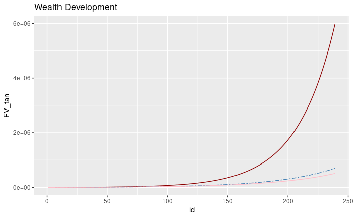

```r
ggplot(ov_list, aes(x=id)) +
  geom_line(aes(y = FV_tan), color = "darkred") +
  geom_line(aes(y = FV_minvar), color="steelblue", linetype="twodash") +
  geom_line(aes(y=FV_bench), color="pink") +
  ggtitle("Wealth Development")
```

The tangency portfolio performed very good related to the others.

```r
PV_tan <- PV(rate = tan_r,nper = 1:239,fv =-invest$FV_tan ,pmt = 0,type = 1)
PV_minvar <- PV(rate =minvar_r, nper=1:239,fv=-invest$FV_minvar,pmt=0,type=1)
PV_bench <- PV(rate=bench_r, nper=1:239, fv=-invest$FV_bench,pmt=0, type=1)
id <- c(1:239)
as.data.frame(PV_tan)
```

| PV_tan |
| --- |
| 5787683.450 |
| 5607460.006 |
| 5432848.563 |
| 5263674.369 |
| 5099768.112 |
| 4940965.755 |
| 4787108.365 |
| 4638041.961 |
| 4493617.356 |
| 4353690.007 |

[output cut: 229 more lines]

```r
as.data.frame(id)
```

| id |
| --- |
| 1 |
| 2 |
| 3 |
| 4 |
| 5 |
| 6 |
| 7 |
| 8 |
| 9 |
| 10 |

[output cut: 229 more lines]

```r
as.data.frame(PV_minvar)
```

| PV_minvar |
| --- |
| 683904.034 |
| 669739.161 |
| 655867.667 |
| 642283.477 |
| 628980.639 |
| 615953.327 |
| 603195.834 |
| 590702.572 |
| 578468.067 |
| 566486.960 |

[output cut: 229 more lines]

```r
as.data.frame(PV_bench)
```

| PV_bench |
| --- |
| 501094.116 |
| 491520.525 |
| 482129.841 |
| 472918.569 |
| 463883.282 |
| 455020.618 |
| 446327.279 |
| 437800.029 |
| 429435.695 |
| 421231.165 |

[output cut: 229 more lines]

```r
ov_list <- cbind(id, PV_tan,PV_minvar,PV_bench)
ov_list <- as.data.frame(ov_list)
invest <- ov_list[239,]
invest
```

|  | id | PV_tan | PV_minvar | PV_bench |
| --- | --- | --- | --- | --- |
| 239 | 239 | 3109.721 | 4695.705 | 5082.059 |

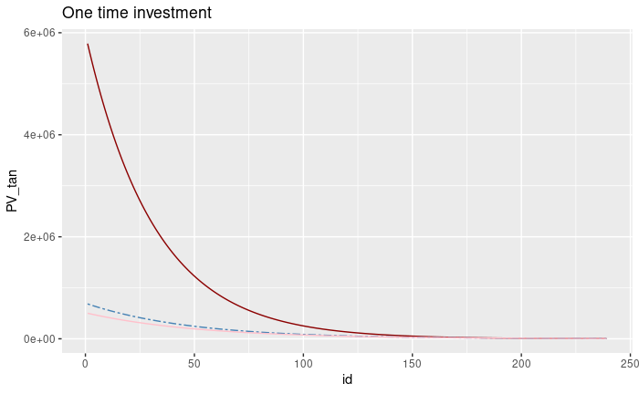

```r
ggplot(ov_list, aes(x=id)) +
  geom_line(aes(y = PV_tan), color = "darkred") +
  geom_line(aes(y = PV_minvar), color="steelblue", linetype="twodash") +
  geom_line(aes(y=PV_bench), color="pink") +
  ggtitle("One time investment")
```

## Exercise 3: Performance Evaluation II

For the same two portfolios and the appropriate benchmark calculate overall performance measures (Sharpe ratio, M2 [assume a risk-fre rate of 0], Treynor Ratio, Jensen’s Alpha and Information ratio). Interpret. Additional do the two market timing regressions (ch 24.4) and see whether your portfolios can “time” the market.

Timing Regressions Treynor and Mazuy = **TM**

```r
ts_ov_tan_port <- ts(ov_tan_port)
ts_ov_minvar_port <- ts(ov_minvar_port)
MarketTiming(Ra = ts_ov_tan_port[,2],Rb = ts_ov_tan_port[,3],Rf = 0,method = "TM")
```

```
           Alpha     Beta    Gamma
 to  0.007279018 1.011562 1.215058
```

```r
MarketTiming(Ra = ts_ov_minvar_port[,2],Rb = ts_ov_minvar_port[,3],Rf = 0,method = "TM")
```

```
           Alpha      Beta     Gamma
 to  0.003237624 0.7565239 0.8547895
```

If the gamma coefficient in the regression is positive, then the estimated equation describes a convex upward-sloping regression “line”. Gamma is a measure of the curvature of the regression line. If gamma is positive as the Tangency Portfolio clearly is it indicates that the manager’s investment strategy demonstrates market timing ability.

## Exercise 4: Active Portfolio Management

Work through trough the demo `demo(relative_ranking)`. Use what you lear here, form an appropriate opinion on the ranking of your assets and optimize a Minimum Variance and Maximum Sharpe ratio Portfolio. Which one performs better?

demo(relative_ranking)

data(edhec)

```r
R <- edhec[,1:4]
```

```r
funds <- colnames(R)
```

#’ Construct initial portfolio with basic constraints.

```r
init.portf <- portfolio.spec(assets=funds)
```

```r
init.portf <- add.constraint(portfolio=init.portf, type="weight_sum",
                              min_sum=0.99, max_sum=1.01)
```

```r
init.portf <- add.constraint(portfolio=init.portf, type="box",min=0.05, max=0.5)
```

```r
init.portf <- add.objective(portfolio=init.portf, type="risk", name="StdDev")
```

```r
init.portf <- add.objective(portfolio=init.portf, type="return", name="mean")

init.portf
```

```
PortfolioAnalytics Portfolio Specification

Call:
portfolio.spec(assets = funds)

Number of assets: 4
Asset Names
[1] "Convertible Arbitrage" "CTA Global"            "Distressed Securities" "Emerging Markets"

Constraints
Enabled constraint types
        - weight_sum
        - box

Objectives:
Enabled objective names
        - StdDev
        - mean
```

> #’ Here we express views on the relative rank of the asset returns.

```r
asset.rank <- c(2, 3, 1, 4)
```

> #’ Use Meucci Fully Flexible Views framework to express views on the relative #’ order of asset returns. #’ Define prior probabilities.

```r
p <- rep(1 / nrow(R), nrow(R))
```

> #’ Express view on the relative ordering of asset returns

```r
m.moments <- meucci.ranking(R, p, asset.rank)
```

```
Checking gradients of objective function.
Derivative checker results: 0 error(s) detected.
Checking gradients of inequality constraints.

Derivative checker results: 0 error(s) detected.
```

#’ Express views using the method described in Almgren and Chriss, > #’ “Portfolios from Sorts”.

```r
 ac.moments <- list()

ac.moments
```

```
list()
```

```r
ac.moments$mu <- ac.ranking(R, asset.rank)
```